# Trading and investment account summary

# For 2020-09-02

Summary text: The equity value of my live trading portfolio changed by -0.15 % (US$ -54.99 ) from US$ 36611.46 to US$ 36556.47 today ( 2020-09-02 ). The trading proceeds in my live account were US$ 32.0799999999999 . The book proceeds in my portfolio changed from US$ 3196.88 to US$ 3109.81

## Portfolio

The below table shows the current positions in the live account as well as their current and total performance. “book_proceed” indicates the unrealized profit in that position.

| symbol | close | closePerc | Total_Change_close | entry_price | position | position_size | entry_position | totalPerc | book_proceed | sector |
| --- | --- | --- | --- | --- | --- | --- | --- | --- | --- | --- |
| KWEB | 72.51 | -0.52 | -38 | 71.48 | 100 | 7251.00 | 7147.60 | 1.43 | 103.4 | Miscellaneous |
| BRK.B | 221.50 | 1.35 | 59.2 | 195.40 | 20 | 4430.00 | 3908.06 | 11.78 | 521.94 | Finance |
| SEAS | 20.78 | 1.71 | -63 | 19.05 | -180 | -3740.40 | -3429.01 | -8.33 | -311.39 | Consumer Services |
| CAKE | 31.29 | 1.76 | 54 | 24.53 | 100 | 3129.00 | 2452.55 | 21.62 | 676.45 | Consumer Services |
| TSLA | 447.25 | -5.85 | -166.77 | 304.17 | 6 | 2683.47 | 1825.02 | 31.99 | 858.45 | Consumer Durables |
| SQ | 162.88 | -2.28 | -56.92 | 143.24 | 15 | 2443.12 | 2148.55 | 12.06 | 294.57 | Technology Services |
| FB | 302.50 | 2.37 | 56 | 296.88 | 8 | 2420.00 | 2375.00 | 1.86 | 45 | Technology Services |
| EZA | 37.61 | -1.96 | 41.25 | 38.54 | -55 | -2068.55 | -2119.70 | 2.47 | 51.15 | Miscellaneous |
| INDA | 34.01 | -0.03 | -0.6 | 33.10 | 60 | 2040.60 | 1985.99 | 2.68 | 54.61 | Miscellaneous |
| GOOG | 1728.29 | 4.07 | 67.58 | 1599.21 | 1 | 1728.29 | 1599.21 | 7.47 | 129.08 | Technology Services |
| MIK | 11.24 | -2.26 | -32.5 | 9.01 | 125 | 1405.00 | 1126.01 | 19.86 | 278.99 | Retail Trade |
| SLV | 25.56 | -2.29 | -30 | 22.90 | 50 | 1278.00 | 1144.95 | 10.41 | 133.05 | Miscellaneous |
| TPR | 14.73 | -0.14 | -1.7 | 14.96 | 85 | 1252.05 | 1271.99 | -1.59 | -19.94 | Retail Trade |
| MGM | 23.71 | 4.15 | 42.52 | 21.88 | 45 | 1067.17 | 984.75 | 7.72 | 82.43 | Consumer Services |
| ABT | 109.39 | 2.67 | 25.56 | 109.71 | 9 | 984.51 | 987.41 | -0.29 | -2.9 | Health Technology |
| UNM | 18.67 | 0.7 | 6.5 | 19.21 | 50 | 933.50 | 960.30 | -2.87 | -26.8 | Finance |
| IAU | 18.55 | -1.33 | -12.5 | 18.96 | 50 | 927.50 | 947.84 | -2.19 | -20.34 | Miscellaneous |
| GOLD | 29.60 | 0.92 | 8.1 | 28.23 | 30 | 888.00 | 847.01 | 4.62 | 40.99 | Non-Energy Minerals |
| RVLV | 21.48 | 0 | 0 | 18.07 | 38 | 816.24 | 686.53 | 15.89 | 129.71 | Retail Trade |
| SWKS | 153.24 | 4.62 | 33.85 | 131.85 | 5 | 766.20 | 659.25 | 13.96 | 106.95 | Electronic Technology |
| CAT | 149.25 | 2.18 | 15.95 | 142.04 | 5 | 746.25 | 710.20 | 4.83 | 36.05 | Producer Manufacturing |
| PPLT | 85.58 | -3.79 | -26.96 | 89.44 | 8 | 684.68 | 715.49 | -4.5 | -30.82 | Miscellaneous |
| DBX | 21.75 | 2.06 | 13.2 | 20.73 | 30 | 652.50 | 621.75 | 4.71 | 30.75 | Technology Services |
| V | 216.38 | 1.41 | 9 | 194.66 | 3 | 649.14 | 583.99 | 10.04 | 65.15 | Finance |
| EPHE | 25.80 | -2.24 | 14.75 | 25.67 | -25 | -645.00 | -641.70 | -0.51 | -3.3 | Miscellaneous |
| PALL | 211.25 | -1.19 | -7.65 | 219.68 | 3 | 633.75 | 659.04 | -3.99 | -25.29 | Miscellaneous |
| UPWK | 15.47 | 1.18 | 7.2 | 14.50 | 40 | 618.80 | 579.96 | 6.28 | 38.84 | Technology Services |
| NFLX | 552.85 | -0.74 | -4.14 | 486.00 | 1 | 552.85 | 486.00 | 12.09 | 66.85 | Consumer Services |
| LMND | 54.65 | -2.72 | -12.24 | 78.07 | 8 | 437.20 | 624.57 | -42.86 | -187.37 | Finance |
| CCL | 16.70 | 1.21 | 5 | 14.54 | 25 | 417.50 | 363.50 | 12.93 | 54 | Consumer Services |
| GDX | 41.78 | 0.24 | 0.8 | 43.89 | 8 | 334.24 | 351.14 | -5.06 | -16.9 | Miscellaneous |
| CRUS | 62.90 | 2.95 | 9.02 | 71.60 | 5 | 314.48 | 358.02 | -13.85 | -43.55 | Electronic Technology |

| symbol | close | closePerc | Total_Change_close | entry_price | position | position_size | entry_position | totalPerc | book_proceed | sector |
| --- | --- | --- | --- | --- | --- | --- | --- | --- | --- | --- |
| Summary | NA | NA | 16.5 | NA | 1193 | 48938.99 | NA | 6.35 | 3109.81 | NA |

[interactive chart not shown]

The performance of my live stock portfolio/trading account vs. my paper trading account and the benchmark ‘SPY’, the US large cap stock market index ETF in percent since June 09 2020.

[interactive chart not shown]

This plot shows a summary of the trading activity on that day. Above 0 is a gain, below is a loss. TRUE indicated live trading account, FALSE is paper trading. A buy side trade is a closed short sale trade and sell side trade is a closed long trade.

[interactive chart not shown]

My current portfolio sorted by sectors. The plot reads clock-wise. Positions below 0 are short positions. Clicking a slice of the pie chart directs to marketwatch.com for further information.

[interactive chart not shown]

These two plots indicate the composition of my portfolio and the change of it over the past week.

[interactive chart not shown]

The inner circle is Monday, the outer circle is Friday.

[interactive chart not shown]

The colors in this plot indicate the daily percentage change of each stock in my portfolio.

[interactive chart not shown]

I classified the stocks in my portfolio by sector. The area represents the size of the position in the portfolio. Long postions

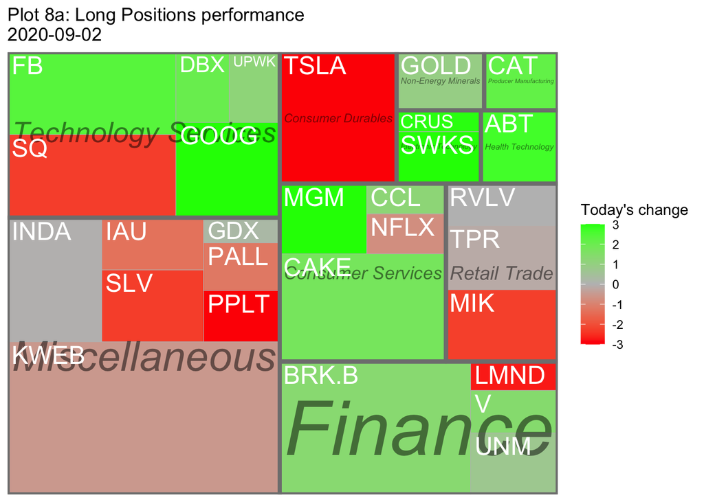

Short postions

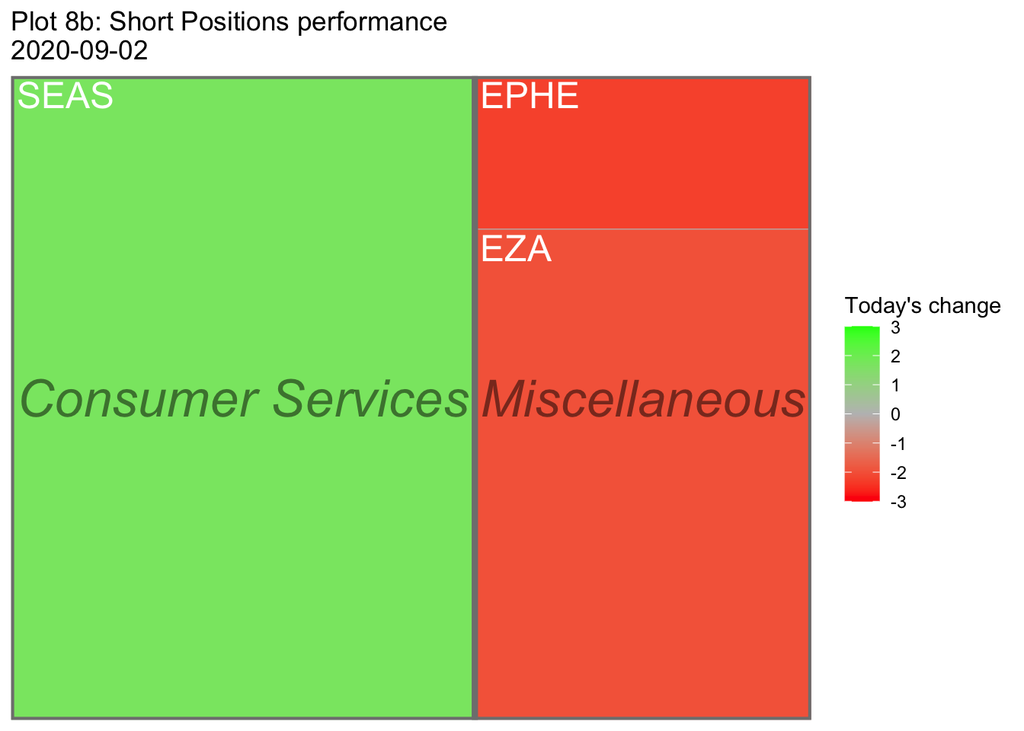

S&P 500 stocks colored by last day performance.

Outliers skew the colors, making the other stocks look pale. I restricted the colors to max of 3 and -3% change. Every stock having higher or lower than 3% change has the same color.

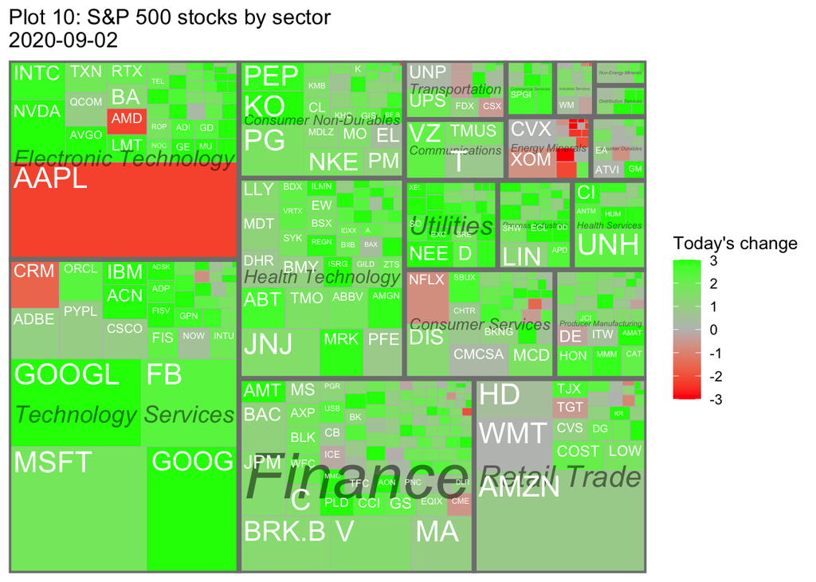

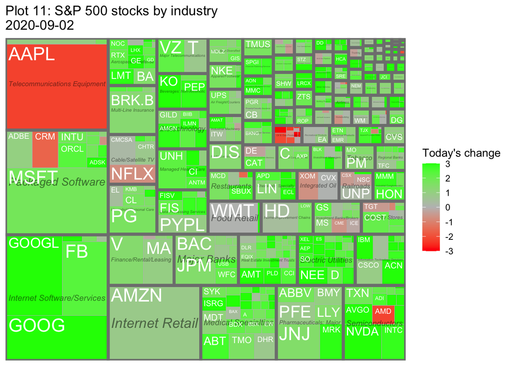